# Testing Raser

# Global adm. boundaries

[Using the package](https://www.gis-blog.com/r-raster-data-acquisition/) `raster` to get admin. boundaries data for Austria.

```r
#install.packages("raster")
library(raster)
library(tidyverse)
```

- installs and loads the package

```r
austria0 <- getData('GADM', country='AUT', level=0)
```

- Arg_1 specifies data set
  - GDAM – global administrative boundaries
- Arg_2 specifies country
  - Use ISO A3 country code
- Arg_3 specifies level of administrative subdivision
  - 0 = country, 1 = state
- Above code returns country boundaries of Austria

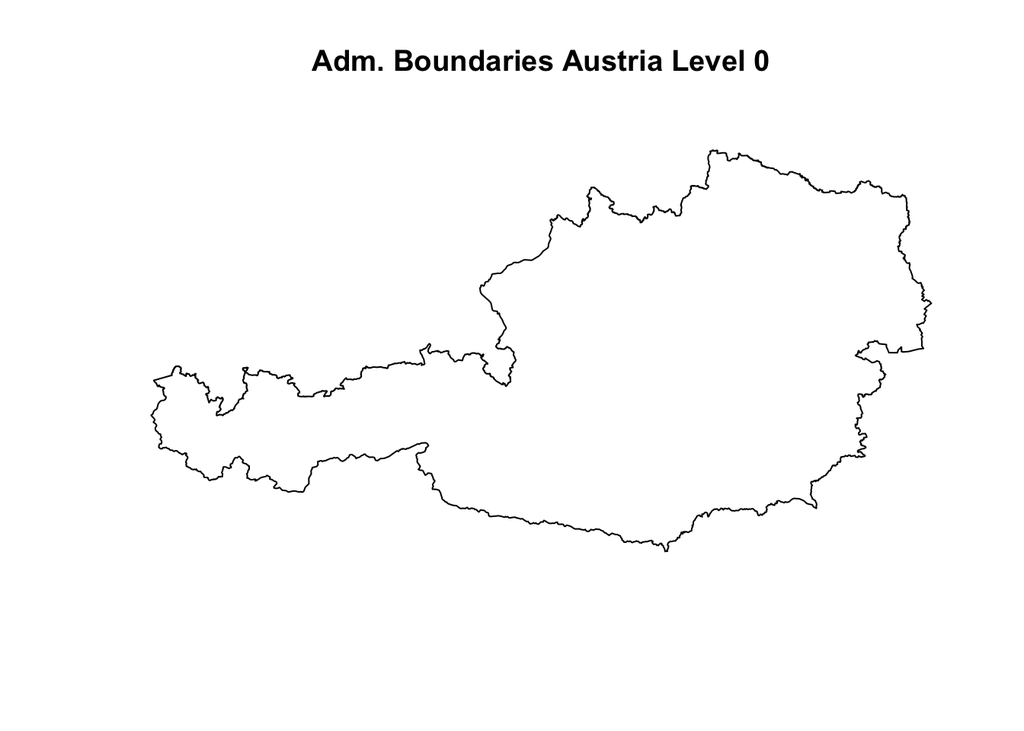

```r
#Get Data
austria0 <- getData('GADM' , country="AUT", level=0)
austria1 <- getData('GADM' , country="AUT", level=1)

#Plot
#par(mfrow(2,1))
plot(austria0, main="Adm. Boundaries Austria Level 0")
```

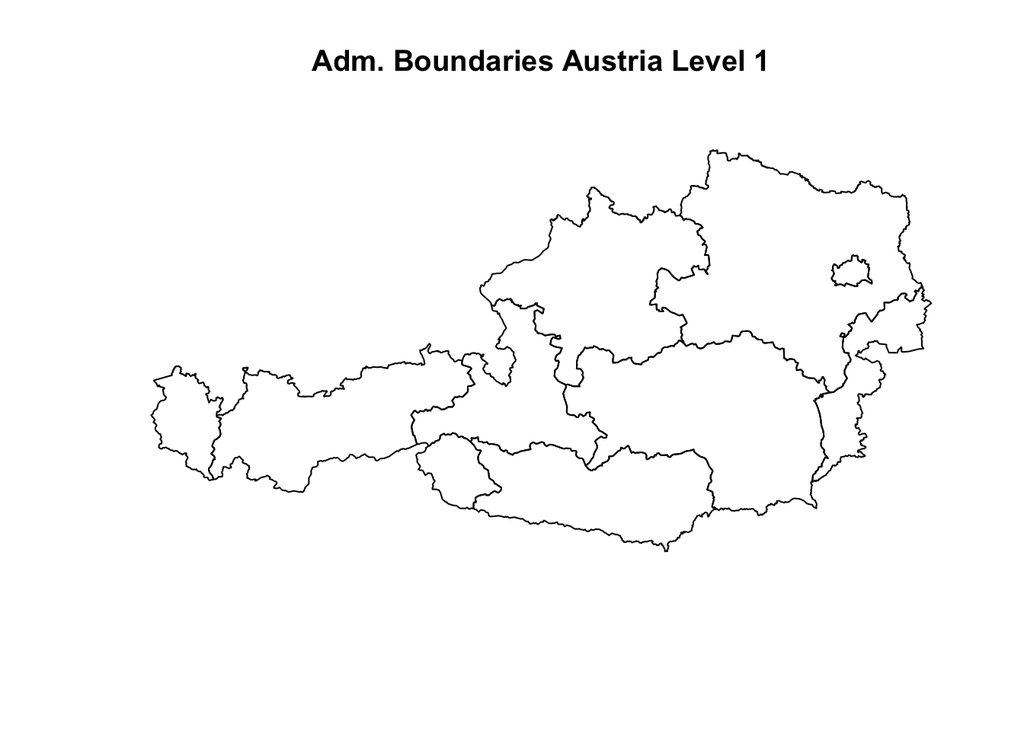

```r
plot(austria1, main="Adm. Boundaries Austria Level 1")
```

- Code prints Country and State borders for Austria

# World Climate

- Similar process for world climate
  - Three arguments
    - Dataset (here, ‘worldclim’)
    - Variable (here, ‘bio’, but also ‘tmin’, ‘tmax’, ‘prec’)
    - Resolutaion (0.5, 2.5, 5, and 10 (minutes of a degree).)
      - res=0.5 requires lon + lat

```r
climate <- getData('worldclim', var='bio', res=2.5)
```

THIS RETURNS A LOT

- BIO1 = Annual Mean Temperature
- BIO2 = Mean Diurnal Range (Mean of monthly (max temp – min temp))
- BIO3 = Isothermality (BIO2/BIO7) (* 100)
- BIO4 = Temperature Seasonality (standard deviation *100)
- BIO5 = Max Temperature of Warmest Month
- BIO6 = Min Temperature of Coldest Month
- BIO7 = Temperature Annual Range (BIO5-BIO6)
- BIO8 = Mean Temperature of Wettest Quarter
- BIO9 = Mean Temperature of Driest Quarter
- BIO10 = Mean Temperature of Warmest Quarter
- BIO11 = Mean Temperature of Coldest Quarter
- BIO12 = Annual Precipitation
- BIO13 = Precipitation of Wettest Month
- BIO14 = Precipitation of Driest Month
- BIO15 = Precipitation Seasonality (Coefficient of Variation)
- BIO16 = Precipitation of Wettest Quarter
- BIO17 = Precipitation of Driest Quarter
- BIO18 = Precipitation of Warmest Quarter
- BIO19 = Precipitation of Coldest Quarter

Tutorial goes on to plot the annual mean temp

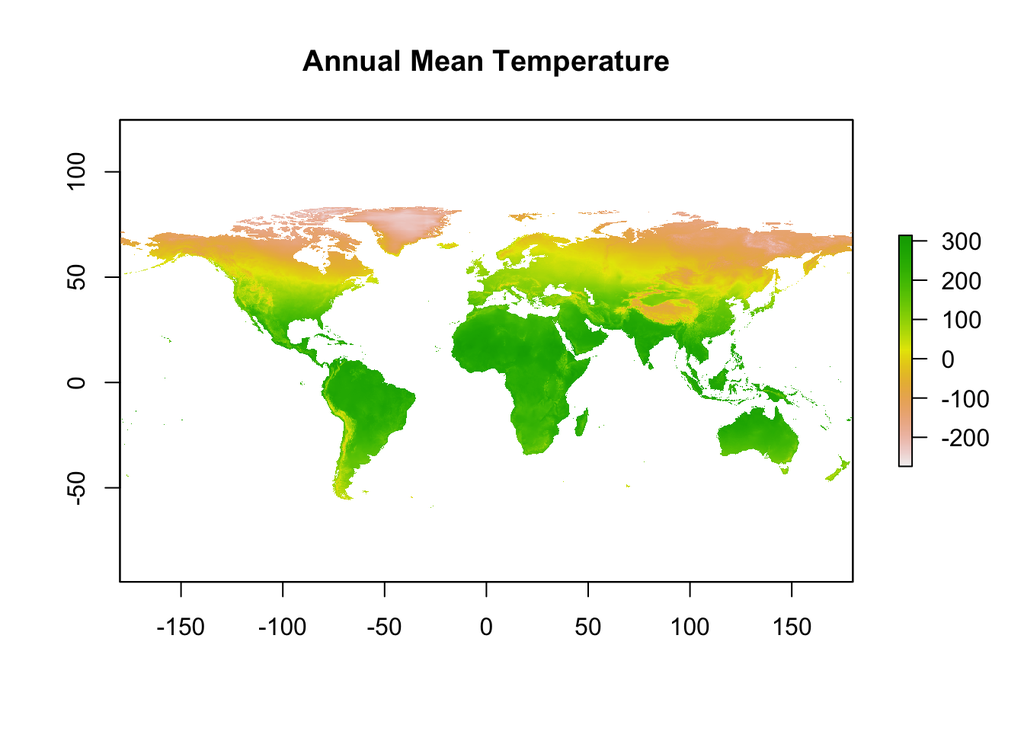

```r
#Plot
plot(climate$bio1, main="Annual Mean Temperature")
```

Lets sidebar and do `BIO5 = Max Temperature of Warmest Month`

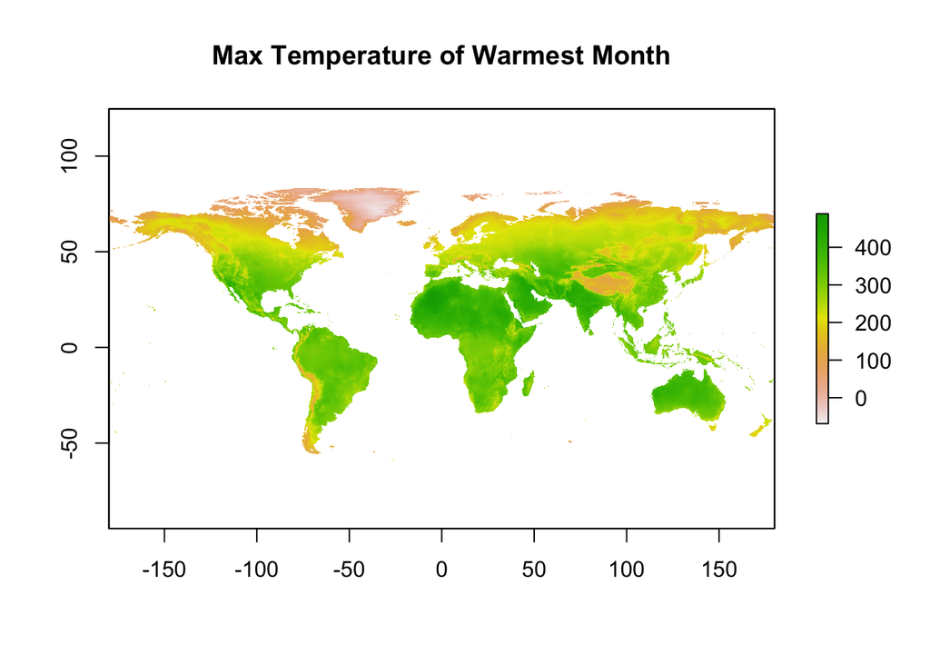

```r
#Plot
plot(climate$bio5, main="Max Temperature of Warmest Month")
```

And BIO6 = Min Temperature of Coldest Month

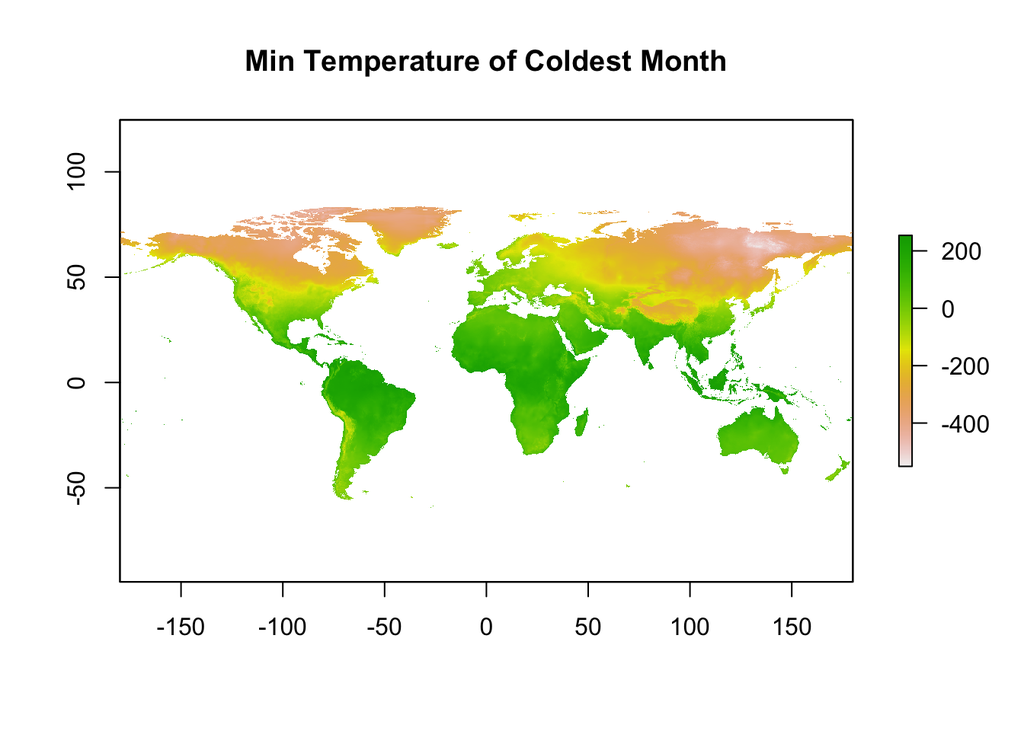

```r
#Plot
plot(climate$bio6, main="Min Temperature of Coldest Month")
```